# Oubriaco_MSDS_422_Assignment_3-Copy1

```python
import pandas as pd  # data frame operations
import numpy as np  # arrays and math functions
import matplotlib.pyplot as plt  # static plotting
import seaborn as sns  # pretty plotting, including heat map
import os
import sklearn
os.chdir() #insert current directory
from sklearn.linear_model import LinearRegression
from sklearn.preprocessing import StandardScaler
from sklearn.preprocessing import RobustScaler
from sklearn.preprocessing import MinMaxScaler
from sklearn.linear_model import SGDRegressor
from sklearn.preprocessing import PolynomialFeatures
from sklearn.metrics import mean_squared_error
from sklearn.model_selection import train_test_split
from sklearn.pipeline import Pipeline
from sklearn.linear_model import Ridge
from sklearn.linear_model import Lasso
from sklearn.linear_model import ElasticNet
from sklearn.base import clone
from sklearn.linear_model import LogisticRegression


train = pd.read_csv("train.csv")
train.head()
```

|  | PassengerId | Survived | Pclass | Name | Sex | Age | SibSp | Parch | Ticket | Fare | Cabin | Embarked |
| --- | --- | --- | --- | --- | --- | --- | --- | --- | --- | --- | --- | --- |
| 0 | 1 | 0 | 3 | Braund, Mr. Owen Harris | male | 22.0 | 1 | 0 | A/5 21171 | 7.2500 | NaN | S |
| 1 | 2 | 1 | 1 | Cumings, Mrs. John Bradley (Florence Briggs Th... | female | 38.0 | 1 | 0 | PC 17599 | 71.2833 | C85 | C |
| 2 | 3 | 1 | 3 | Heikkinen, Miss. Laina | female | 26.0 | 0 | 0 | STON/O2. 3101282 | 7.9250 | NaN | S |
| 3 | 4 | 1 | 1 | Futrelle, Mrs. Jacques Heath (Lily May Peel) | female | 35.0 | 1 | 0 | 113803 | 53.1000 | C123 | S |
| 4 | 5 | 0 | 3 | Allen, Mr. William Henry | male | 35.0 | 0 | 0 | 373450 | 8.0500 | NaN | S |

Getting a sense of the data here. Not a lot of columns, but with codes we could have a lot to work with binary attributes.

```python
train.info() #let's see how populated data is
```

```
<class 'pandas.core.frame.DataFrame'>
RangeIndex: 891 entries, 0 to 890
Data columns (total 12 columns):
PassengerId    891 non-null int64
Survived       891 non-null int64
Pclass         891 non-null int64
Name           891 non-null object
Sex            891 non-null object
Age            714 non-null float64
SibSp          891 non-null int64
Parch          891 non-null int64
Ticket         891 non-null object
Fare           891 non-null float64
Cabin          204 non-null object
Embarked       889 non-null object
dtypes: float64(2), int64(5), object(5)
memory usage: 83.6+ KB
```

Looks like the Cabin is severely underpopulated. As a result I won't look to fill the nulls. Age is more manageable. Next I want to see what the tickets look like to see if there are any codes we can get out of that.

```python
train["Ticket"].value_counts()
```

```
1601                7
CA. 2343            7
347082              7
347088              6
CA 2144             6
3101295             6
382652              5
S.O.C. 14879        5
347077              4
19950               4
PC 17757            4
W./C. 6608          4
4133                4
17421               4
349909              4
```

[output cut: 47 more lines]

It looks like there isn't much of a pattern, as a result, I will ignore this attribute.

Next let's look at statistics on the numeric variables.

```python
train.describe()
```

|  | PassengerId | Survived | Pclass | Age | SibSp | Parch | Fare |
| --- | --- | --- | --- | --- | --- | --- | --- |
| count | 891.000000 | 891.000000 | 891.000000 | 714.000000 | 891.000000 | 891.000000 | 891.000000 |
| mean | 446.000000 | 0.383838 | 2.308642 | 29.699118 | 0.523008 | 0.381594 | 32.204208 |
| std | 257.353842 | 0.486592 | 0.836071 | 14.526497 | 1.102743 | 0.806057 | 49.693429 |
| min | 1.000000 | 0.000000 | 1.000000 | 0.420000 | 0.000000 | 0.000000 | 0.000000 |
| 25% | 223.500000 | 0.000000 | 2.000000 | 20.125000 | 0.000000 | 0.000000 | 7.910400 |
| 50% | 446.000000 | 0.000000 | 3.000000 | 28.000000 | 0.000000 | 0.000000 | 14.454200 |
| 75% | 668.500000 | 1.000000 | 3.000000 | 38.000000 | 1.000000 | 0.000000 | 31.000000 |
| max | 891.000000 | 1.000000 | 3.000000 | 80.000000 | 8.000000 | 6.000000 | 512.329200 |

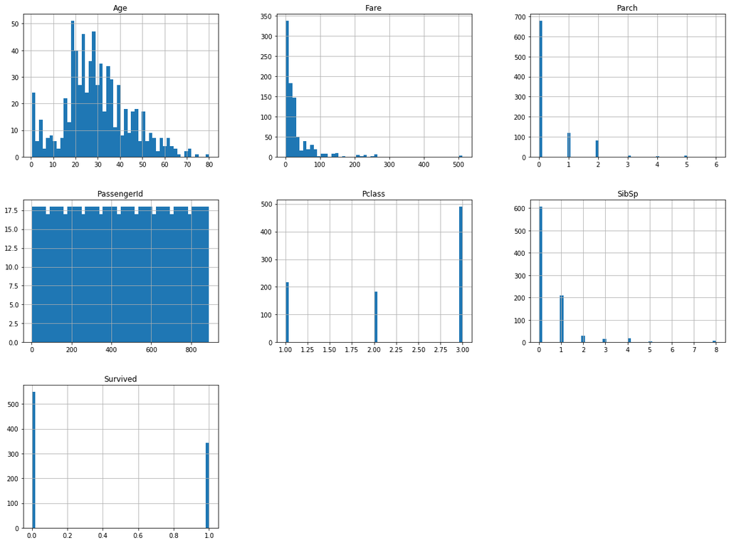

```python
%matplotlib inline
import matplotlib.pyplot as plt
train.hist(bins=50, figsize=(20,15))
plt.show()
```

As we can see age is right skewed so we will look at filling na's with the median soon. No major surprises looking at things. More people were lower class, and more people had lower fares and most were not in families.

Next, before we do any feature engineering let's look at what's correlated with survival with our given variables

```python
corr_matrix = train.corr()
corr_matrix["Survived"].sort_values(ascending=False)
```

```
Survived       1.000000
Fare           0.257307
Parch          0.081629
PassengerId   -0.005007
SibSp         -0.035322
Age           -0.077221
Pclass        -0.338481
Name: Survived, dtype: float64
```

Looksl ike Pclass and Fare have the largest correlations for now. Let's see what happens as we stack variables and convert categorical data.

```python
#fill na age with the median
train['Age'] = train['Age'].fillna(28)
```

Next let's separate our ages into categories so we can more easily use them as binary variables.

```python
def define_age_cat(X,buckets,labels):
        X["Age_categories"] = pd.cut(X["Age"],buckets,labels=labels)
        return X

buckets = [0, 5, 12, 18, 35, 60, 100]
labels = ['Infant', 'Child', 'Teenager', 'Young Adult', 'Adult', 'Senior']
```

```python
define_age_cat(train, buckets, labels)
```

[output not shown]

891 rows × 13 columns

### Stacking Variables

This is the first time I've tried stacking variables. I had a few submissions of my work which I'll discuss more in the paper, but it seemed like more stacking the better. The submission I had where I didn't use Age_Class_Sex performed much worse than my other submissions.

The thought behind this stacking was that if we know certain ages, classes, and sex's had a higher likeliehood of surviving, if we stack them together we can get good binary data on specific combinations of these things.

```python
#since we are combining different data types we need to add .astype(str) to make sure they combine
train['Age_Class_Sex'] = train['Age_categories'].astype(str) + '_' + train['Pclass'].astype(str) + '_' + train['Sex'].astype(str)
train['Class_Sex'] = train['Pclass'].astype(str) + '_' + train['Sex'].astype(str)
train.head()
```

|  | PassengerId | Survived | Pclass | Name | Sex | Age | SibSp | Parch | Ticket | Fare | Cabin | Embarked | Age_categories | Age_Class_Sex | Class_Sex |
| --- | --- | --- | --- | --- | --- | --- | --- | --- | --- | --- | --- | --- | --- | --- | --- |
| 0 | 1 | 0 | 3 | Braund, Mr. Owen Harris | male | 22.0 | 1 | 0 | A/5 21171 | 7.2500 | NaN | S | Young Adult | Young Adult_3_male | 3_male |
| 1 | 2 | 1 | 1 | Cumings, Mrs. John Bradley (Florence Briggs Th... | female | 38.0 | 1 | 0 | PC 17599 | 71.2833 | C85 | C | Adult | Adult_1_female | 1_female |
| 2 | 3 | 1 | 3 | Heikkinen, Miss. Laina | female | 26.0 | 0 | 0 | STON/O2. 3101282 | 7.9250 | NaN | S | Young Adult | Young Adult_3_female | 3_female |
| 3 | 4 | 1 | 1 | Futrelle, Mrs. Jacques Heath (Lily May Peel) | female | 35.0 | 1 | 0 | 113803 | 53.1000 | C123 | S | Young Adult | Young Adult_1_female | 1_female |
| 4 | 5 | 0 | 3 | Allen, Mr. William Henry | male | 35.0 | 0 | 0 | 373450 | 8.0500 | NaN | S | Young Adult | Young Adult_3_male | 3_male |

Looks like the stacking worked.

Next we will drop the passengerId, Ticket, and Cabin columns. This is because PassengerId and Ticket seem to have no correlation to survival whatsoever, and Cabin is not populated enough to warrant filling null values.

```python
train = train.drop(columns = ['PassengerId','Ticket','Cabin'])
```

Next we are going to set up a new binary column called TravelAlone. This looks at the parent and sibling columns and if they are populated, then you know they traveled with a someone.

I originally then deleted with Sibsp and Parch columns, but I actually got better results with the test set when I also put those columns through one hot encoding.

```python
train['TravelAlone']=np.where((train["SibSp"]+train["Parch"])>0, 0, 1)
#train.drop('SibSp', axis=1, inplace=True)
#train.drop('Parch', axis=1, inplace=True)
```

Next I took a function I saw someone else use that I liked for splitting fare's into groups. The groups feel a little arbitrary as they don't quite correlate to the percentiles we found in out .describe() function earlier, but they play a good role in correlation later.

```python
def fare_group(fare):
    a= ''
    if fare <= 4:
        a = 'Very_low'
    elif fare <= 10:
        a = 'low'
    elif fare <= 20:
        a = 'mid'
    elif fare <= 45:
        a = 'high'
    else:
        a = "very_high"
    return a

train['fare_group'] = train['Fare'].map(fare_group)
```

Now we are going to get dummies to create binary variaables for all of the categorical data that we are interested in. As noted before I toyed with having less variables added for this, but at least for this specific instance... it was the more the merrier.

```python
train = pd.get_dummies(train,columns=['Age_Class_Sex','Parch','SibSp','Sex', 'Embarked','Age_categories','Pclass','Class_Sex','fare_group'])
```

Now I just want to see a general heatmap to see if anything sticks out

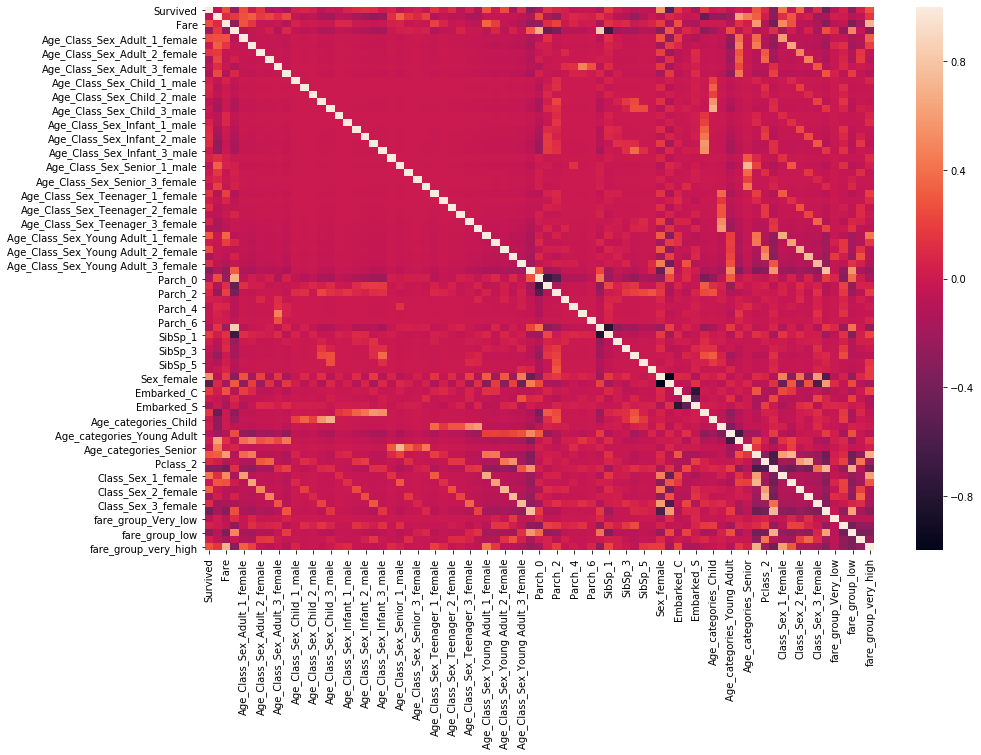

```python
traincorr = train.corr() #get correlation data
plt.subplots(figsize=(15,10)) #graph was too small at first, resize for readability
sns.heatmap(traincorr) #produce heatmap
```

Not too many surprises here, a lot of the sibling/travel alone and gender columns had negative correlations.

Let's look more specifically at what is positively and negatively correlated with survival. I am more curious to compare to the feautre selection we will do later.

```python
corr_matrix = train.corr()
corr_matrix["Survived"].sort_values(ascending=False).head(16)
```

```
Survived                              1.000000
Sex_female                            0.543351
Class_Sex_1_female                    0.412581
Class_Sex_2_female                    0.337329
Pclass_1                              0.285904
Age_Class_Sex_Young Adult_1_female    0.281671
fare_group_very_high                  0.265841
Fare                                  0.257307
Age_Class_Sex_Young Adult_2_female    0.249134
Age_Class_Sex_Adult_1_female          0.248260
SibSp_1                               0.173076
Embarked_C                            0.168240
Age_categories_Infant                 0.150304
Age_Class_Sex_Adult_2_female          0.145252
Age_Class_Sex_Teenager_1_female       0.134985
Parch_1                               0.134174
Name: Survived, dtype: float64
```

```python
corr_matrix["Survived"].sort_values(ascending=True).head(16)
```

```
Sex_male                           -0.543351
Class_Sex_3_male                   -0.407925
Pclass_3                           -0.322308
Age_Class_Sex_Young Adult_3_male   -0.320244
fare_group_low                     -0.275028
TravelAlone                        -0.203367
Class_Sex_2_male                   -0.172920
Age_Class_Sex_Young Adult_2_male   -0.163693
Embarked_S                         -0.155660
Age_Class_Sex_Adult_3_male         -0.147937
Parch_0                            -0.147408
Age_Class_Sex_Adult_2_male         -0.126062
SibSp_0                            -0.115867
Age_Class_Sex_Teenager_3_male      -0.109415
fare_group_Very_low                -0.085343
Age_categories_Young Adult         -0.077053
Name: Survived, dtype: float64
```

```python
# correlation heat map setup for seaborn
def corr_chart(df_corr):
    corr=df_corr.corr()
    #screen top half to get a triangle
    top = np.zeros_like(corr, dtype=np.bool)
    top[np.triu_indices_from(top)] = True
    fig=plt.figure()
    fig, ax = plt.subplots(figsize=(12,12))
    sns.heatmap(corr, mask=top, cmap='coolwarm',
        center = 0, square=True,
        linewidths=.5, cbar_kws={'shrink':.5},
        annot = True, annot_kws={'size': 9}, fmt = '.3f')
    plt.xticks(rotation=45) # rotate variable labels on columns (x axis)
    plt.yticks(rotation=0) # use horizontal variable labels on rows (y axis)
    plt.title('Correlation Heat Map')
    plt.savefig('plot-corr-map.pdf',
        bbox_inches = 'tight', dpi=None, facecolor='w', edgecolor='b',
        orientation='portrait', papertype=None, format=None,
        transparent=True, pad_inches=0.25, frameon=None)
```

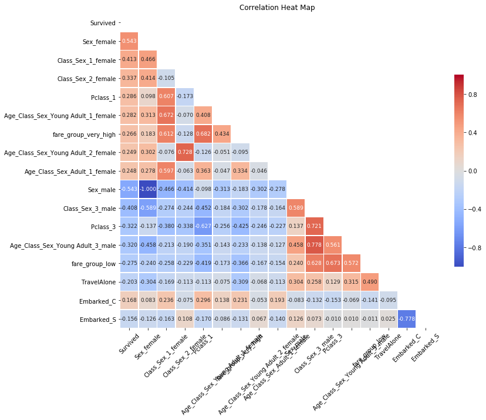

```python
top_corr = train[['Survived','Sex_female','Class_Sex_1_female','Class_Sex_2_female','Pclass_1'
                  ,'Age_Class_Sex_Young Adult_1_female','fare_group_very_high','Age_Class_Sex_Young Adult_2_female'
                  ,'Age_Class_Sex_Adult_1_female','Sex_male','Class_Sex_3_male','Pclass_3','Age_Class_Sex_Young Adult_3_male'
                  ,'fare_group_low','TravelAlone','Embarked_C','Embarked_S']]
corr_chart(df_corr = top_corr)
```

```python
#these three columns were not in test data
train = train.drop(columns = ['Age_Class_Sex_Infant_1_male', 'Age_Class_Sex_Infant_1_female','Age_Class_Sex_Senior_3_female'])
```

Next, we want to pick our optimal feature set. Using Recrusive feature elimination with cross validation, it will run through a process to figure out what features should be used.

[output not shown]

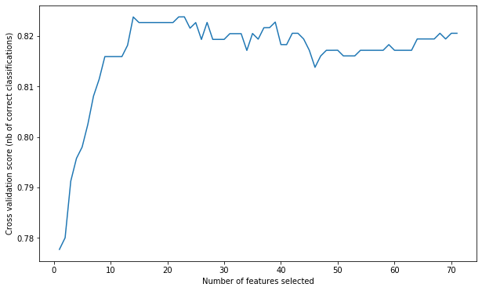

```python
from sklearn.feature_selection import RFECV
X = train.loc[:, 'TravelAlone':'fare_group_very_high']
y = train['Survived']
# Create the RFE object and compute a cross-validated score.
# The "accuracy" scoring is proportional to the number of correct classifications
rfecv = RFECV(estimator=LogisticRegression(solver = 'lbfgs'), step=1, cv=10, scoring='accuracy')
rfecv.fit(X, y)

print("Optimal number of features: %d" % rfecv.n_features_)
print('Selected features: %s' % list(X.columns[rfecv.support_]))

# Plot number of features VS. cross-validation scores
plt.figure(figsize=(10,6))
plt.xlabel("Number of features selected")
plt.ylabel("Cross validation score (nb of correct classifications)")
plt.plot(range(1, len(rfecv.grid_scores_) + 1), rfecv.grid_scores_)
plt.show()
```

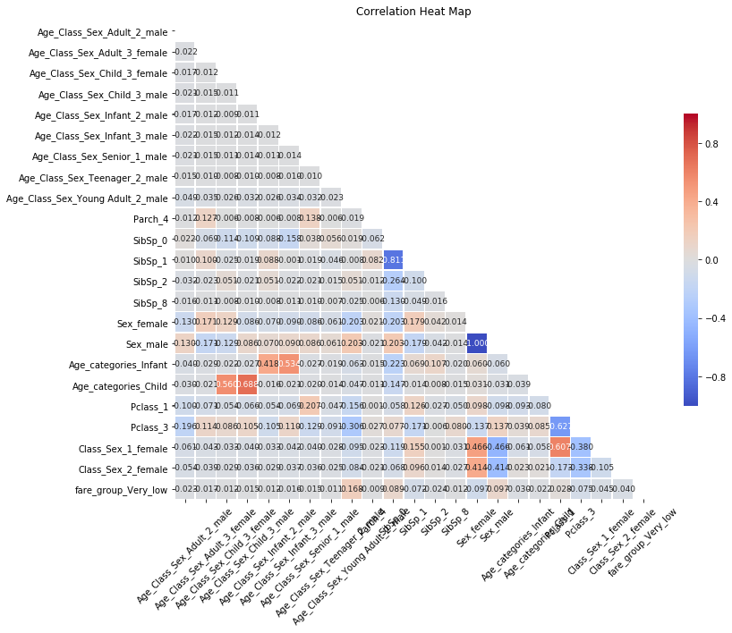

```python
log_corr = train[['Age_Class_Sex_Adult_2_male', 'Age_Class_Sex_Adult_3_female', 'Age_Class_Sex_Child_3_female', 'Age_Class_Sex_Child_3_male', 'Age_Class_Sex_Infant_2_male', 'Age_Class_Sex_Infant_3_male', 'Age_Class_Sex_Senior_1_male', 'Age_Class_Sex_Teenager_2_male', 'Age_Class_Sex_Young Adult_2_male', 'Parch_4', 'SibSp_0', 'SibSp_1', 'SibSp_2', 'SibSp_8', 'Sex_female', 'Sex_male', 'Age_categories_Infant', 'Age_categories_Child', 'Pclass_1', 'Pclass_3', 'Class_Sex_1_female', 'Class_Sex_2_female', 'fare_group_Very_low']]
corr_chart(df_corr = log_corr)
```

## Creating the Models

Now despite the RECV recommending to use only 23 of the features, I have shared the version that had the highest score on kaggle for me (78.9% using Bayes, tied for 2589th). Ultimately the best score came from using literally every feature I had. Today was not a win for over training data.

```python
#setting up the columns that were originally recommended
cols = ['Parch_4', 'Parch_6', 'SibSp_0', 'SibSp_1', 'SibSp_2', 'SibSp_3', 'SibSp_4', 'SibSp_5', 'SibSp_8', 'Sex_female', 'Sex_male', 'Embarked_S', 'Age_categories_Infant', 'Age_categories_Child', 'Age_categories_Adult', 'Age_categories_Senior', 'Pclass_1', 'Pclass_3', 'Class_Sex_1_female', 'Class_Sex_2_female', 'Class_Sex_2_male', 'Class_Sex_3_female', 'fare_group_Very_low']
#for the best one, I just took all binary columns
X=train.loc[:, 'TravelAlone':'fare_group_very_high']
Y=train['Survived'] #the dependent variable
logreg = LogisticRegression(solver='lbfgs')
logreg.fit(X, Y)
logreg.score(X, Y)
```

```
0.8305274971941639
```

```python
from sklearn.naive_bayes import GaussianNB
classifier = GaussianNB()
classifier.fit(X, Y)
classifier.score(X,Y)
```

```
0.8125701459034792
```

```python
from sklearn.naive_bayes import BernoulliNB
bern = BernoulliNB()
bern.fit(X,Y)
bern.score(X,Y)
```

```
0.7890011223344556
```

### Cross validation

Now we will cross validate these two methods by using a k fold method via the cross_val_score

```python
from sklearn.model_selection import cross_val_score
scores_accuracy = cross_val_score(logreg, X, Y, cv=10, scoring='accuracy')
scores_log_loss = cross_val_score(logreg, X, Y, cv=10, scoring='neg_log_loss')
scores_auc = cross_val_score(logreg, X, Y, cv=10, scoring='roc_auc')
print('K-fold cross-validation results:')
print(logreg.__class__.__name__+" average accuracy is %2.3f" % scores_accuracy.mean())
print(logreg.__class__.__name__+" average log_loss is %2.3f" % -scores_log_loss.mean())
print(logreg.__class__.__name__+" average auc is %2.3f" % scores_auc.mean())
```

```
K-fold cross-validation results:
LogisticRegression average accuracy is 0.821
LogisticRegression average log_loss is 0.422
LogisticRegression average auc is 0.866
```

```python
scores_accuracy = cross_val_score(classifier, X, Y, cv=10, scoring='accuracy')
scores_log_loss = cross_val_score(classifier, X, Y, cv=10, scoring='neg_log_loss')
scores_auc = cross_val_score(classifier, X, Y, cv=10, scoring='roc_auc')
print('K-fold cross-validation results:')
print(classifier.__class__.__name__+" average accuracy is %2.3f" % scores_accuracy.mean())
print(classifier.__class__.__name__+" average log_loss is %2.3f" % -scores_log_loss.mean())
print(classifier.__class__.__name__+" average auc is %2.3f" % scores_auc.mean())
```

```
K-fold cross-validation results:
GaussianNB average accuracy is 0.786
GaussianNB average log_loss is 3.708
GaussianNB average auc is 0.856
```

By all accounts here the Logistic Regression performed better. This was true for every round of testing I had, and it performed better in each of the submissions to Kaggle as well besides the best submission where I used all columns.

Next let's visualize the roc_curves:

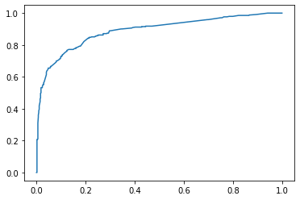

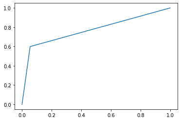

```python
from sklearn.metrics import roc_curve, auc
y_score = logreg.decision_function(X)

FPR, TPR, _ = roc_curve(Y, y_score)
ROC_AUC = auc(FPR, TPR)
plt.plot(FPR, TPR)
plt.show()
y_score = classifier.fit(X, Y).predict(X)
FPR, TPR, _ = roc_curve(Y, y_score)
ROC_AUC = auc(FPR, TPR)
plt.plot(FPR, TPR)
plt.show()
```

Alas, let's make the same changes to the test-set so they can be put in both of the algorithms:

```python
test = pd.read_csv("test.csv")
test['Age'] = test['Age'].fillna(28)
def define_age_cat(X,buckets,labels):
        X["Age_categories"] = pd.cut(X["Age"],buckets,labels=labels)
        return X

buckets = [0, 5, 12, 18, 35, 60, 100]
labels = ['Infant', 'Child', 'Teenager', 'Young Adult', 'Adult', 'Senior']
define_age_cat(test, buckets, labels)
test['Age_Class_Sex'] = test['Age_categories'].astype(str) + '_' + test['Pclass'].astype(str) + '_' + test['Sex'].astype(str)
test['Class_Sex'] = test['Pclass'].astype(str) + '_' + test['Sex'].astype(str)
test = test.drop(columns = ['Ticket','Cabin'])
test['TravelAlone']=np.where((test["SibSp"]+test["Parch"])>0, 0, 1)
def fare_group(fare):
    a= ''
    if fare <= 4:
        a = 'Very_low'
    elif fare <= 10:
        a = 'low'
    elif fare <= 20:
        a = 'mid'
    elif fare <= 45:
        a = 'high'
    else:
        a = "very_high"
    return a

test['fare_group'] = test['Fare'].map(fare_group)
test = pd.get_dummies(test,columns=['Age_Class_Sex','Parch','SibSp','Sex', 'Embarked','Age_categories','Pclass','Class_Sex','fare_group'])
cols = ['Parch_4', 'Parch_6', 'SibSp_0', 'SibSp_1', 'SibSp_2', 'SibSp_3', 'SibSp_4', 'SibSp_5', 'SibSp_8', 'Sex_female', 'Sex_male', 'Embarked_S', 'Age_categories_Infant', 'Age_categories_Child', 'Age_categories_Adult', 'Age_categories_Senior', 'Pclass_1', 'Pclass_3', 'Class_Sex_1_female', 'Class_Sex_2_female', 'Class_Sex_2_male', 'Class_Sex_3_female', 'fare_group_Very_low']
#two of the dummy variables were not in the test data: ['Age_Class_Sex_Infant_1_male', 'Age_Class_Sex_Infant_1_female']['Age_Class_Sex_Senior_3_female']
test = test.drop(columns = ['Parch_9'])
Xtest=test.loc[:, 'TravelAlone':'fare_group_very_high']
```

```python
test['Survived'] = logreg.predict(Xtest) #get the prediction
logreg_submission = test[['PassengerId','Survived']] #save data for csv
logreg_submission.to_csv('logreg_submission_5.csv',index=False) #export to csv
```

```python
bayes_test = test #create new df to have the bayes test
bayes_test['Survived'] = classifier.predict(Xtest) #get the prediction
bayes_submission = bayes_test[['PassengerId','Survived']] #save data for csv
bayes_submission.to_csv('bayes_submission_5.csv',index=False) #export to csv
```

```python
bern_test = test
bern_test['Survived'] = bern.predict(Xtest)
bern_submission = bern_test[['PassengerId','Survived']]
bern_submission.to_csv('bern_submission_1.csv',index=False)
```

```python
#attempt using less features for Bayes - did not have better results
data = pd.read_csv("train.csv")
data['Age'].fillna(28)
data['Embarked'].fillna('S')
data.dropna(axis=0, inplace=True)
data['Sex'] = data['Sex'].replace(["female", "male"], [0, 1])
data['Embarked'] = data['Embarked'].replace(['S', 'C', 'Q'], [1, 2, 3])
data['Age'] = pd.qcut(data['Age'], 10, labels=False)
data = data[['Sex', 'Embarked', 'Age', 'Fare', 'Parch', 'Pclass', 'SibSp','Survived']]
x = data[['Sex', 'Embarked', 'Age', 'Fare', 'Parch', 'Pclass', 'SibSp']]
y = data['Survived']
gaus = GaussianNB()
gaus.fit(x, y)
gaus.score(x,y)
```

```
0.7595628415300546
```

```python
testdata = pd.read_csv("test.csv")
testdata['Age'].fillna(28)
testdata['Embarked'].fillna('S')
testdata.dropna(axis=0, inplace=True)
testdata['Sex'] = testdata['Sex'].replace(["female", "male"], [0, 1])
testdata['Embarked'] = testdata['Embarked'].replace(['S', 'C', 'Q'], [1, 2, 3])
testdata['Age'] = pd.qcut(testdata['Age'], 10, labels=False)
Xtest = testdata[['Sex', 'Embarked', 'Age', 'Fare', 'Parch', 'Pclass', 'SibSp']]
```

```python
testdata['Survived'] = gaus.predict(Xtest) #get the prediction
bayes_submission = test[['PassengerId','Survived']] #save data for csv
bayes_submission.to_csv('bayes_submission_6.csv',index=False) #export to csv
```

```python
#test one: ['Sex_female', 'Sex_male', 'Embarked_S', 'Age_categories_Infant', 'Age_categories_Adult', 'Age_Class_Sex_Adult_1_female', 'Age_Class_Sex_Adult_2_male', 'Age_Class_Sex_Adult_3_female', 'Age_Class_Sex_Child_1_male', 'Age_Class_Sex_Child_2_male', 'Age_Class_Sex_Child_3_female', 'Age_Class_Sex_Child_3_male', 'Age_Class_Sex_Infant_2_male', 'Age_Class_Sex_Senior_1_male', 'Age_Class_Sex_Teenager_2_male', 'Age_Class_Sex_Young Adult_1_female', 'Age_Class_Sex_Young Adult_2_male', 'Pclass_1', 'Pclass_3', 'Class_Sex_1_female', 'Class_Sex_2_female', 'Class_Sex_3_female', 'fare_group_Very_low']
#test two: 'Sex_female', 'Sex_male', 'Embarked_S', 'Age_categories_Infant', 'Age_categories_Adult', 'Age_Class_Sex_Adult_1_female', 'Age_Class_Sex_Adult_2_male', 'Age_Class_Sex_Adult_3_female', 'Age_Class_Sex_Child_1_male', 'Age_Class_Sex_Child_2_male'
#test three: ['Sex_female', 'Sex_male', 'Embarked_S', 'Age_categories_Infant', 'Age_Class_Sex_Adult_1_female', 'Age_Class_Sex_Adult_2_male', 'Age_Class_Sex_Adult_3_female', 'Age_Class_Sex_Child_1_male', 'Age_Class_Sex_Child_2_male', 'Age_Class_Sex_Child_3_female', 'Age_Class_Sex_Child_3_male', 'Age_Class_Sex_Infant_2_male', 'Age_Class_Sex_Senior_1_male', 'Age_Class_Sex_Teenager_2_male', 'Age_Class_Sex_Young Adult_1_female', 'Age_Class_Sex_Young Adult_2_male', 'Pclass_1', 'Pclass_3', 'Class_Sex_1_female', 'Class_Sex_2_female', 'Class_Sex_3_female', 'fare_group_Very_low']
```